# Laboratorium przetwarzania obrazów i grafiki komputerowej

## Sesja 6 - Grafika komputerowa - wstęp. Biblioteka VTK

### Łódź 2017

### Zadania do wykonania

#### 1. Obrazy do pracy podczas laboratrium

Ze [strony domowej przedmiotu](http://www.eletel.p.lodz.pl/med/pl/index.php?option=com_jotloader&view=categories&cid=99_b3c1de9aa6c8258566cc1b3370d1e750&Itemid=346) pobierz plik *lab6.zip*. Plik zapisz **w swoim katalogu roboczym** na dysku *D:\* , a następnie rozpakuj. Użyj programu *7zip* lub polecenia systemowego *Wyodrębnij wszystkie...*.

#### 2. Biblioteki programistyczne do tworzenia grafiki komputerowej

Istnieje kilka bibliotek które są przeznaczone do wizualizacji danych jako trójwymiarowych obiektów graficznych. Pośród najpopularnijszych można wymienić OpenGL [[1](https://www.opengl.org),[2](http://nehe.gamedev.net)], The Visualization Toolkit [[1](http://www.vtk.org),[2](http://www.midasjournal.org/)] czy Mayavi2 [[1](http://code.enthought.com/projects/mayavi/),[2](http://docs.enthought.com/mayavi/mayavi/)].

#### 3. Visualization Toolkit (VTK)

Biblioteka [VTK](http://www.vtk.org) jest zbiorem darmowych klas otwartego oprogramowania do tworzenia trójwymiarowej grafiki komputerowej, wizualizacji, posiada również możliwość przetwarzania obrazów. VTK jest napisane w języku C++ i jest dostępne dla głównych systemów operacyjnych: Windows, Linux, Unix i MacOS.

Proces generowania obrazów 2D lub 3D z wykorzystaniem komputera nazywany jest **renderowaniem**. Dane są zamieniane na obiekty graficzne, a następnie są wyświetlane na ekranie komputera. W prcesie tym odpwiednio modelowane są odbicia i załamania światła od powierzchni wyświetlanego obiektu, cienie, a nawet wpływ atmosfery (np. mgła).

W procesie renderowania możemy wyróżnić trzy podstawowe elementy:

1. źródła światła,
2. wyświetlane obiekty (nazywane *aktorami*),
3. kamerę.

Najprostszym źródłem światła jest takie które umieszczono bardzo daleko od oświetlanej sceny (w *nieskończoności*), dzięki temu emitowane we wszystikich kierunkach promienie są równoległe względem siebie.

Biorąc pod uwagę ustawienie kamery w scenie renderowany obiekt może być widziany w różno sposób. W tym aspekcie możemy ustawić odpowiednie parametry kamery:

1. położenie,
2. orientację,
3. punkt ogniskowania kamery,
4. metodę rzutowania kamery (rzutowanie równoległe lub perspektywiczne),
5. współrzędne obcinania sceny przez kamerę.

Ważnym elementem sceny 3D jest obiekt który jest renderowany - *aktor*. W praktyce każdy taki obiekt jest reprezentowany przez zbiór podstawowych form geometrycznych (ang. *primitives*) takich jak: punkty, linie, wielokąty, krzywe itp.

Aby zbudować pełną scenę 3D i odpowienio zamodelowć obiekty (aktorów) w bibliotece VTK konieczne jest wykorzystanie siedmiu podsawowych elementów:

1. vtkRendererWindow - zarządza oknem pojawiającym się na ekranie monitora, wewnątrz takiego okna może znajdować się kilka rendererów.
2. vtkRenderer - koordynuje proces renderowania włączając w to obliczenia światła, kamery i wszystkich aktorów.
3. vtkLight - definiuje parametry źródła światła (lub kilku źródeł).
4. vtkCamera - definiuje kierunek patrzenia na scenę, punkt ogniskowania oraz inne parametry.
5. vtkActor - reprezentuje obiekt renderowany w scenie 3D wraz z jego właściwościami (ang. *properties*) takimi jak: kolor, typ cieniowania, rodzaj powierzchni, itp.. Aktor jest usytuowany w konkretnym miejscu sceny 3D - ma określone współrzędne w układzie kartezjańskim.
6. vtkProperty - określa wygląd właściwości wyglądu aktora takie jak: kolor, przeźroczystość, reakcje na światło (np. stopień odbijania światła) oraz sposób reprezentacji za pomocą pełnych powierzchni, siatka lub punktów.
7. vtkMapper - zamienia geometrię która opisuje aktora na zbiór wielokątów łatwych do renderowania przez kartę graficzną. Kilku aktorów może być przypisanych do tego sameg mappera.

Biblioteka VTK jest tak zaprojektowana, że większość parametrów i ustawiwń związanych z kamerą, światłem i właściwościami aktorów jest dobierana w sposób automatyczny, a zarazem dosyć optymalny. Istnieje jednak możliwość modyfikacji wszystkich ustawień przez programistę.

Dokumentacja klas zawartych w VTK znajduje się na stronie domowej projektu [[1](http://www.vtk.org/documentation/),[2](http://www.vtk.org/doc/release/6.3/html/),[3](http://www.vtk.org/doc/release/6.3/html/annotated.html),[4](http://www.vtk.org/doc/release/6.3/html/classes.html)].

#### 4. Wczytanie obrazów do wyświetlania

**UWAGA** W poniższej komórce zostaną zdefiniowane wszystkie obrazy (zrzuty z ekranu), które będą wyświetlane w dalszej części instrukcji. Proszę nie przepisywać ani nie wykonywać tej komórki.

```python
from IPython.display import Image
trojkaty = Image(filename='obrazy_2017/lab6_trojkaty.png')
stozki = Image(filename='obrazy_2017/lab6_cones.png')
sfery_walce_szescian = Image(filename='obrazy_2017/lab6_sfery_walce_szescian.png')
renderery = Image(filename='obrazy_2017/lab6_renderery.png')
obrazy2D = Image(filename='obrazy_2017/lab6_obrazy.png')
```

#### 5. Renderowanie figur płasnkich - trójkąty

W katalogu *lab6_dane_kody* znajdują się skrypty z odpowiednimi programami. Przeanalizuj kody zapisane w plikach *vtk_1_triangle1.py* oraz *vtk_2_triangle2.py*. Po wykonaniu każdego z programów na ekranie monitora powinny pojawić się jeden obiekt w kształcie trójkąta jak na rysunku poniżej.

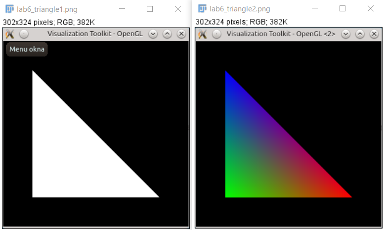

```python
trojkaty
```

#### 6. Stożki

Zapoznaj się z kodami programów *vtk_3_cone1.py* i *vtk_4_cone2.py*. W pierwszym z nich geometria figury została utworzona automatycznie - z wykorzystaniem odpowiedniej klasy biblioteki VTK. W drugim natomiast jest stworzona samodzielnie.

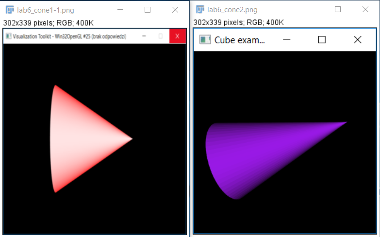

```python
stozki
```

#### 7. Kula, walec i sześcian

Zapoznaj się z kodami programów *vtk_5_sphere1.py*, *vtk_6_sphere1_and_cylinder.py*, *vtk_7_cylinder* i *vtk_8_cube.py*. W programach do wyświetlania sześcianu i walca wszystkie punkty są definiowane przez użytkownika. Natomiast kody w których renderowana jest sfera i sfera z walcem geometrię figur definują przy wykorzystaniu odpowiednich funkcji.

W kodzie programu dotyczącym rysowania sfery zmień wybrane parametry dotyczące geometrii

- PhiResolution()
- ThetaResolution()
- Radius()
- Positon()

oraz wyglądu. Do tego celu wykorzystaj funkcjęGetPRoperty() i zmodyfikuj wartośći za pomocą następujących funkcji:

- SetColor() - kolor RGB ($0 \div 1$)
- SetDiffuse() - zakres wartości ($0 \div 1$)
- SetSpecular() - zakres wartości ($0 \div 1$)
- SetSpecularPower() -($0 \div 255$)
- SetBackground() - metoda dotycząca obiktur renderera.

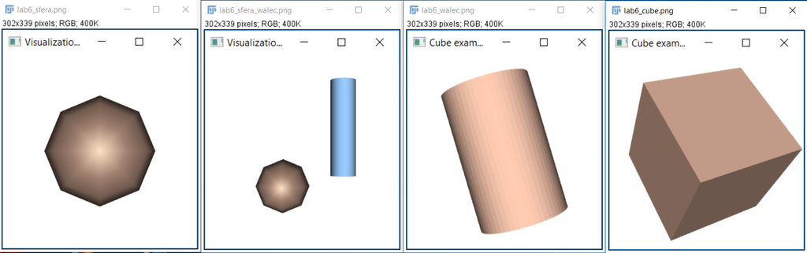

```python
sfery_walce_szescian
```

#### 8. Podział okna renderowania na części

Umieść cztery niezależne obiekty renderowania (klasa *vtkRenderer()*) w jednym oknie na ekranie monitora. W każdej renderowanej scnenie wyświetl inny obiekt. Za pomocą metody *SetBackground()* zróżnicuj kolory scen. Zamieść każdy obiket klasy *vtkRenderer* w innej części okna (*vtkRendererWindow()*):

Do tego celu zmodyfikuj kod programu *vtk_9_renderery.py*.

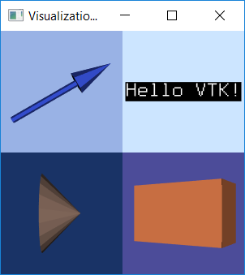

```python
renderery
```

#### 9. Wyświetlanie obrazów 2D

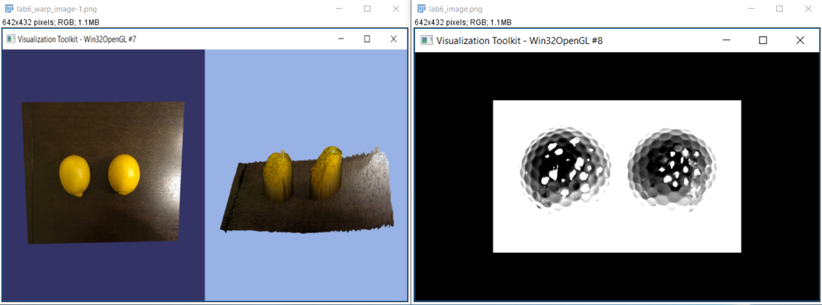

```python
obrazy2D
```

#### Ostatnia aktualizacja: 16.04.2017